# Homework 5

Alejandro Rosales

October 27, 2019

# Variables

ID: The property ID number

List.Price: The price the owner is selling the property for

Duplex: Whether the property is a duplex or not

Bedrooms: The number of bedrooms

Baths: Total number of bathrooms

Full.Baths: Number of full bathrooms

Half.Baths: Number of half bathrooms

Floors: Number of stories

Subdivision: The subdivision the property is in

Square.Footage: The estimated floor area inside the house

Year.Built: The year the house was constructed

Acreage: The size of the lot

New.Owned: Whether the house has been lived in previously

House.Style: The type of property (traditional, condo, ranch, etc.)

Pool: Whether the property has a private pool or not

Dock: Whether the property has a private dock or not

Fenced.Yard: Whether the property has a fenced - in yard or not

Screened.Porch: Whether the property has a screened porch or not

Golf.Course: Whether the property is located on a golf course or not

Fireplace: Whether the property has a fireplace or not

n.Fireplaces: The number of fireplaces

# Problems

```r
MountPleasantRealEstateData <- read_csv("MountPleasantRealEstateData.csv")
head(MountPleasantRealEstateData)
```

```
## # A tibble: 6 x 21
##      ID List.Price Duplex Bedrooms Baths Full.Baths Half.Baths Floors
##   <dbl>      <dbl> <chr>     <dbl> <dbl>      <dbl>      <dbl>  <dbl>
## 1   115     369900 Yes           3   2.5          2          1      2
## 2   117     375000 Yes           3   2.5          2          1      2
## 3     5     769900 No            4   3.5          3          1      2
## 4     9     699990 No            4   3.5          3          1      2
## 5    62     436625 No            4   3            3          0      2
## 6    61     446900 No            3   2.5          2          1      2
## # ... with 13 more variables: Subdivision <chr>, Square.Footage <dbl>,
## #   Year.Built <dbl>, Acreage <dbl>, New.Owned <chr>, House.Style <chr>,
## #   Pool <chr>, Dock <chr>, Fenced.Yard <chr>, Screened.Porch <chr>,
## #   Golf.Course <chr>, Fireplace <chr>, n.Fireplaces <dbl>
```

**Problem 1** Draw a side-by-side boxplot for the list price (List.Price) of three subdivisions (Subdivision) and interpret your result.

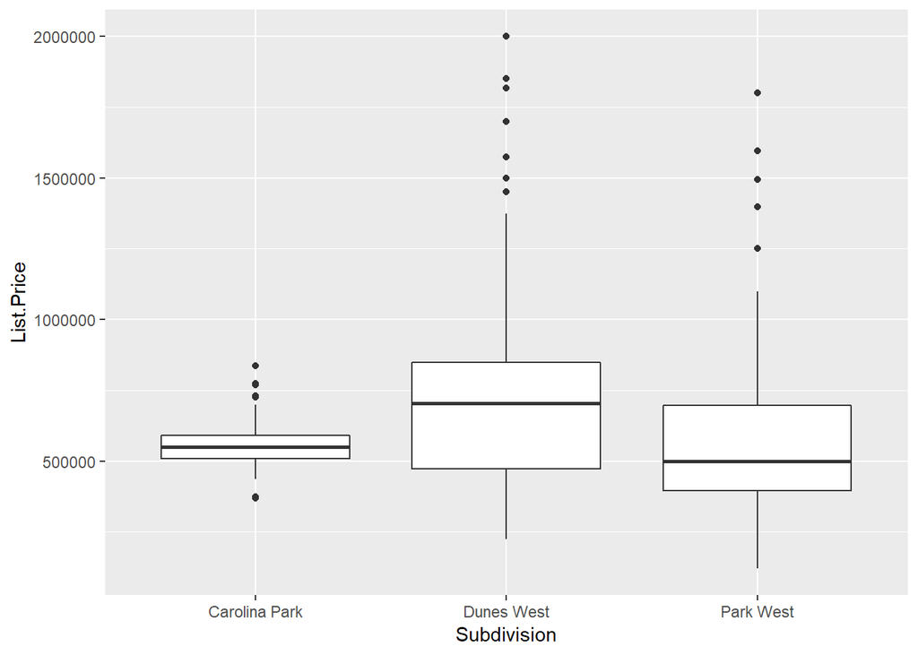

```r
ggplot(MountPleasantRealEstateData) +
  geom_boxplot(aes(x=Subdivision, y=List.Price) )
```

According to the graph, it appears that the highest mean for List.Price is Dunes West, while the lowest mean List.Price is Park West. Carolina Park has the lowest variability. The highest List.Price belongs to Dunes West ~ 200,0000.

**Problem 2** Fit an ANCOVA model for the list price and Subdivision, including the Square Footage as a covariate. Construct residual diagnostic plots of that fit. Do there appear to be any assumption violations?

```r
ancova.model1 <- lm(List.Price ~ Subdivision + Square.Footage + Subdivision:Square.Footage, data=MountPleasantRealEstateData)
summary(ancova.model1)
```

```
##
## Call:
## lm(formula = List.Price ~ Subdivision + Square.Footage + Subdivision:Square.Footage,
##     data = MountPleasantRealEstateData)
##
## Residuals:
##     Min      1Q  Median      3Q     Max
## -378613  -82760  -28406   50290  959532
##
## Coefficients:
##                                        Estimate Std. Error t value
## (Intercept)                           186303.35  135731.99   1.373
## SubdivisionDunes West                -382360.36  146431.73  -2.611
## SubdivisionPark West                 -339155.48  145196.43  -2.336
## Square.Footage                           141.65      50.64   2.797
## SubdivisionDunes West:Square.Footage     129.34      52.88   2.446
## SubdivisionPark West:Square.Footage      113.38      53.44   2.122
##                                      Pr(>|t|)
## (Intercept)                           0.17117
## SubdivisionDunes West                 0.00959 **
## SubdivisionPark West                  0.02033 *
## Square.Footage                        0.00557 **
## SubdivisionDunes West:Square.Footage  0.01517 *
## SubdivisionPark West:Square.Footage   0.03489 *
## ---
## Signif. codes:  0 '***' 0.001 '**' 0.01 '*' 0.05 '.' 0.1 ' ' 1
##
## Residual standard error: 167800 on 239 degrees of freedom
## Multiple R-squared:  0.717,  Adjusted R-squared:  0.7111
## F-statistic: 121.1 on 5 and 239 DF,  p-value: < 2.2e-16
```

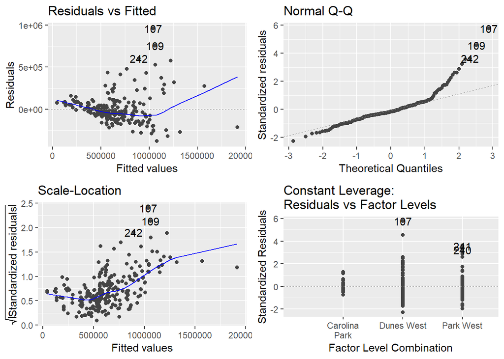

```r
autoplot(ancova.model1)
```

The normality assumption appears to be violated as the right side appears to be lifted from the diagnoal line. The sample size is big so it is not of much concern. There is concern regarding the residuals (linerality) with the pattern forming of sort of a swosh and constant error variance line is not straight and horizontal (large increases in Scale-Location plot).

**Problem 3** Use a Box-Cox plot to determine whether a transformation of the response variable could improve the model fit. If the plot suggests a transformation, fit the model with that transformation and comment on the residual diagnostic plots for that model. Does it make sense to do a transformation?

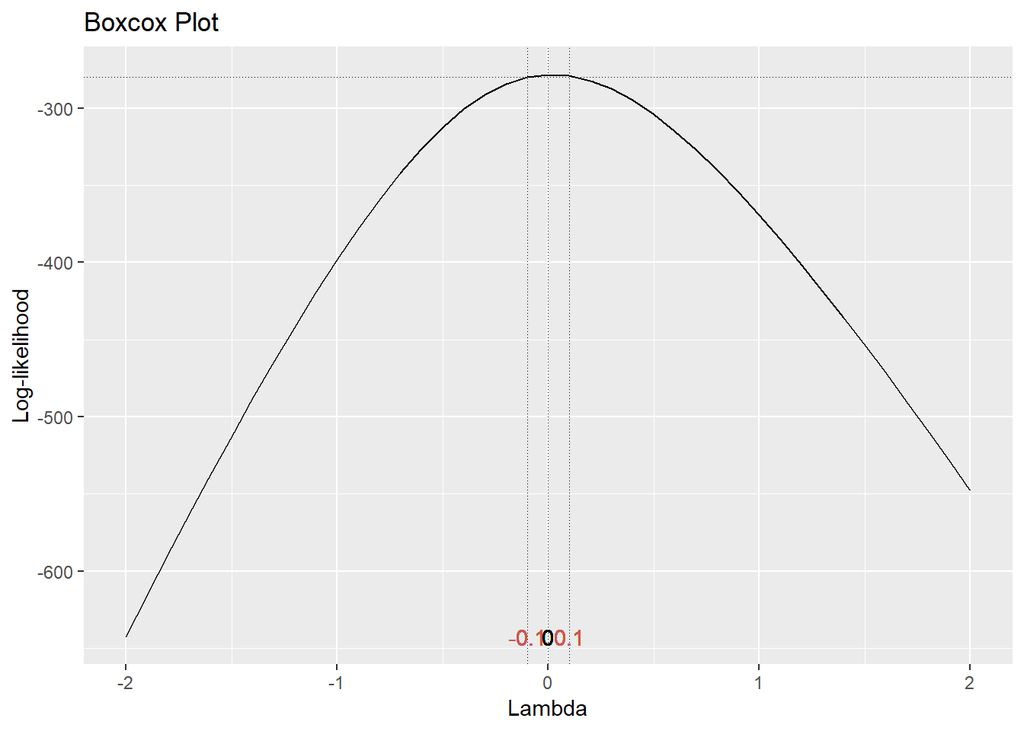

```r
gg_boxcox(ancova.model1)
```

The box-cox plot suggests raising the response variable to 0 to fit the model.

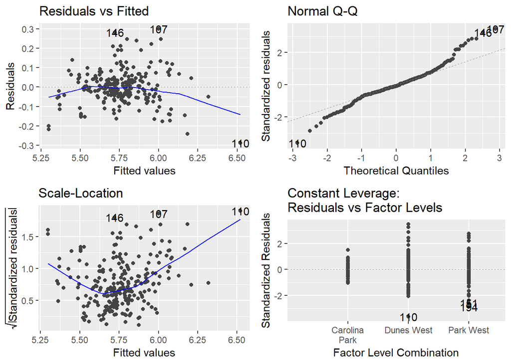

```r
ancova.model2 <- lm(log10(List.Price) ~ Subdivision + Square.Footage + Subdivision:Square.Footage, data=MountPleasantRealEstateData)
autoplot(ancova.model2)
```

The normality assumption appears to be lifted from the left side less drastically. The rediuales appears to be better as are is not as much of a pattern to them and constant error variance appears to look better but not by much.

Yes it makes sense to do a transformation because it benifits the assumptions enough to valiadate the extra work that goes into the transformation of a model.

**Problem 4** Is the interaction between square footage and subdivision significant? (Hint: this should be based on a single test statistic.)

```r
ancova.model3 <- lm(log10(List.Price) ~ Subdivision + Square.Footage, data=MountPleasantRealEstateData)

anova(ancova.model2, ancova.model3, test="Chisq")
```

```
## Analysis of Variance Table
##
## Model 1: log10(List.Price) ~ Subdivision + Square.Footage + Subdivision:Square.Footage
## Model 2: log10(List.Price) ~ Subdivision + Square.Footage
##   Res.Df    RSS Df Sum of Sq  Pr(>Chi)
## 1    239 1.8275
## 2    241 1.9418 -2  -0.11427 0.0005687 ***
## ---
## Signif. codes:  0 '***' 0.001 '**' 0.01 '*' 0.05 '.' 0.1 ' ' 1
```

The Chisq test tells me that there is a significant difference between a model with the interaction between square footage and subdivision and a model without as the $p-value = 0.0005687$.

**Problem 5** Remove the unusual observation (row 110) and refit the transformed model. Are there any dramatic changes to the results?

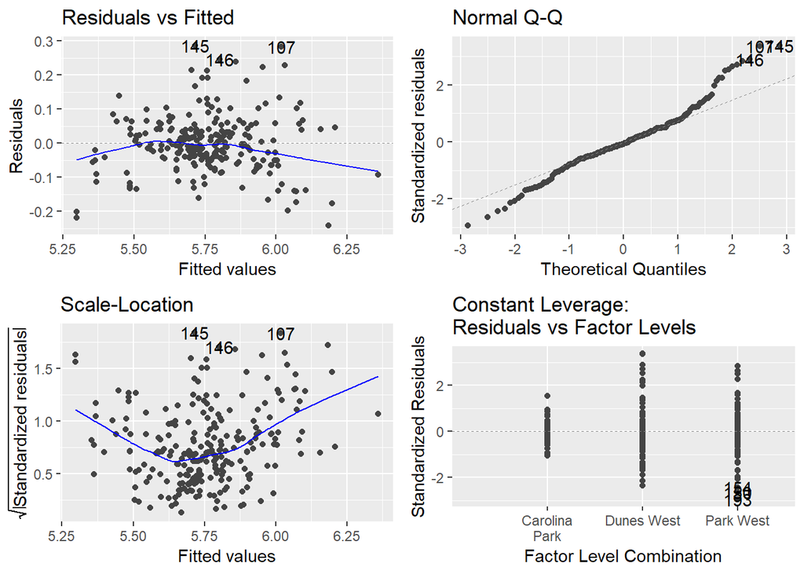

```r
ancova.model3 <- lm(log10(List.Price) ~ Subdivision + Square.Footage + Subdivision:Square.Footage, data=MountPleasantRealEstateData[-110,])
autoplot(ancova.model3)
```

No there do not appear to be any dramatic results.

**Problem 6** Fit an ANCOVA model (with transformation as determined in part 3) for the list price and Subdivision, including the covariates Square Footage and Bedrooms without removing the unusual observation. Keep the interaction with Square Footage, but don’t add an interaction for Bedrooms yet. Is the number of Bedrooms a significant predictor of list price? Use 90% as the significance level.

```r
ancova.model5 <- lm(log10(List.Price) ~ Subdivision + Square.Footage + Bedrooms + Subdivision:Square.Footage, data=MountPleasantRealEstateData)

ancova.model6 <- lm(log10(List.Price) ~ Subdivision + Square.Footage + Subdivision:Square.Footage, data=MountPleasantRealEstateData)

anova(ancova.model5, ancova.model6, test="Chisq")
```

```
## Analysis of Variance Table
##
## Model 1: log10(List.Price) ~ Subdivision + Square.Footage + Bedrooms +
##     Subdivision:Square.Footage
## Model 2: log10(List.Price) ~ Subdivision + Square.Footage + Subdivision:Square.Footage
##   Res.Df    RSS Df  Sum of Sq Pr(>Chi)
## 1    238 1.8193
## 2    239 1.8275 -1 -0.0081997   0.3003
```

At a 90% significance level the number of Bedrooms is not a significant predictor of list price in this problem as p-value is greater than .1 at 0.3003.

**Problem 7** Fit an ANCOVA model (with transformation as determined in part 3) for the list price and Subdivision, including the number of Bedrooms as a covariate (with an interaction this time) without removing the unusual observation. Is the number of Bedrooms a significant predictor now? Use 90% as the significance level. Why is this result different from part 6? (Hint: think about the relationship between Bedrooms and Square Footage.)

```r
ancova.model7 <- lm(log10(List.Price) ~ Subdivision + Bedrooms + Subdivision:Bedrooms, data=MountPleasantRealEstateData)

anova(ancova.model5, ancova.model7, test="Chisq")
```

```
## Analysis of Variance Table
##
## Model 1: log10(List.Price) ~ Subdivision + Square.Footage + Bedrooms +
##     Subdivision:Square.Footage
## Model 2: log10(List.Price) ~ Subdivision + Bedrooms + Subdivision:Bedrooms
##   Res.Df    RSS Df Sum of Sq  Pr(>Chi)
## 1    238 1.8193
## 2    239 4.5795 -1   -2.7601 < 2.2e-16 ***
## ---
## Signif. codes:  0 '***' 0.001 '**' 0.01 '*' 0.05 '.' 0.1 ' ' 1
```

At a 90% significance level the number of Bedrooms is a significant predictor of list price in this problem as p-vlaue is less than .1 at < 2.2e-16. This is different because now since bedrooom is by itslef and square footage which increases with the amount of bedrooms, is accounting for the change in list price as its taking credit for square footages work in a way.

**Problem 8** Consider the model fitted in 3, what is the estimated difference in the value of a square foot of a home in Carolina Park vs Park west?

```r
summary(ancova.model2)
```

```
##
## Call:
## lm(formula = log10(List.Price) ~ Subdivision + Square.Footage +
##     Subdivision:Square.Footage, data = MountPleasantRealEstateData)
##
## Residuals:
##      Min       1Q   Median       3Q      Max
## -0.28952 -0.04322 -0.00693  0.04158  0.30070
##
## Coefficients:
##                                        Estimate Std. Error t value
## (Intercept)                           5.449e+00  7.073e-02  77.046
## SubdivisionDunes West                -1.846e-01  7.630e-02  -2.419
## SubdivisionPark West                 -3.044e-01  7.566e-02  -4.024
## Square.Footage                        1.112e-04  2.639e-05   4.214
## SubdivisionDunes West:Square.Footage  5.007e-05  2.755e-05   1.817
## SubdivisionPark West:Square.Footage   8.583e-05  2.785e-05   3.082
##                                      Pr(>|t|)
## (Intercept)                           < 2e-16 ***
## SubdivisionDunes West                 0.01631 *
## SubdivisionPark West                 7.69e-05 ***
## Square.Footage                       3.56e-05 ***
## SubdivisionDunes West:Square.Footage  0.07047 .
## SubdivisionPark West:Square.Footage   0.00229 **
## ---
## Signif. codes:  0 '***' 0.001 '**' 0.01 '*' 0.05 '.' 0.1 ' ' 1
##
## Residual standard error: 0.08744 on 239 degrees of freedom
## Multiple R-squared:  0.8078, Adjusted R-squared:  0.8038
## F-statistic: 200.9 on 5 and 239 DF,  p-value: < 2.2e-16
```

```r
10 ^ 8.583e-05
```

```
## [1] 1.000198
```

Looking at the summary for the fitted model from part 3, the model predicts a difference in value between Carolina Park and Park west of 8.583e-05 log(1 dollar) for each square foot increase of the house. Transforming it ends up being $1.000198

**Problem 9** Use the model fitted in 3 to estimate, with 95% confidence, the mean selling price (in the original, untransformed scale) of 2500 sq ft 3-bedroom homes in Dunes West. (Hint: you may have to fit the model with a transformation then do the inverse of that transformation once you have your confidence interval.)

```r
predict(ancova.model2, newdata=data.frame(Square.Footage=2500, Bedrooms=3, Subdivision="Dunes West"), int="conf")
```

```
##        fit      lwr      upr
## 1 5.667678 5.645083 5.690273
```

```r
10^5.667678
```

```
## [1] 465241
```

```r
10^5.645083
```

```
## [1] 441654.8
```

```r
10^5.690273
```

```
## [1] 490086.8
```

The estimate, with 95% confidence, for the mean selling price of 2500 sq ft 3-bedroom homes in Dunes West is the interval: fit: $465,241 lwr: $441,654.8 and upr: $490,086.8.